# Spatial Transcriptomics

- Show All Code
- Hide All Code
- View Source

GeoDiff Based Quality Control

Published

2026-07-23

# GeoDiff processing (2)

**Protocol reader guidance**

This notebook is written for users applying the workflow to their own dataset. Read each section in order, confirm required inputs before running code sections, and use the YAML parameters at the top of the file to adapt paths and thresholds for your study design.

**Before you run**

Validate input data and metadata column names first. Most runtime issues in protocol use are caused by path mismatches, missing files, or dataset-specific column naming differences.

**Path portability check**

The setup section checks the full input and output path lengths against `portable_path_limit` before analysis begins. Generated diagnostic filenames are shortened in a fixed, repeatable way when needed, and the fixed filenames that later stages must read are never renamed. Fix any path flagged as too long before continuing.

**Reproducibility caution**

When editing parameters, record exactly what changed (paths, thresholds, model options) in your run notes so later figures and conclusions can be reproduced during review and publication.

This notebook runs the **GeoDiff filtering stage** for GeoMx data after QC.

A segment, or area of illumination (AOI), is the profiled GeoMx collection area within a region of interest (ROI). One ROI may contain several segments (for example PanCK, A-SMA, CD45, Stroma). The segment is the unit of data in this pipeline: one segment corresponds to one DCC file and one column of the GeoMx object, so all counts reported below are segment counts.

## What this step does

The workflow applies model-based background estimation, identifies features and segments to retain, and writes a filtered object for normalisation and differential expression.

## Why this matters

This step moves from broad QC filtering to model-based feature/segment selection. Decisions made here directly affect normalisation behaviour and differential expression model stability in later stages.

**What later comparisons cover**

The saved `GeoDiff_spatial_data.RDS` object is the **GeoDiff-filtered count object**. It contains count-like expression values after GeoDiff background modeling, probe aggregation, high-signal feature marking, and segment retention filtering. It is not the GeoDiff-normalized `normmat` matrix created in `3_Normalisation.qmd`.

Later comparisons between GeoDiff-filtered and non-GeoDiff DE branches therefore reflect both this filtering step and the chosen normalization/modeling path. Treat those outputs as comparisons of whole workflow paths, not of normalization alone.

## What you decide next

- If model diagnostics and retained segment/feature patterns look acceptable, proceed to `3_Normalisation.qmd`.
- If diagnostics indicate poor fit or excessive filtering, adjust GeoDiff parameters and rerun before moving forward.

This document explains **what is being computed and why**. It intentionally avoids interpretation of output values.

This workflow is outlined in the following references:

- [GeoDiff Bioconductor workflow vignette (kidney WTA example)](https://bioconductor.org/packages/devel/bioc/vignettes/GeoDiff/inst/doc/Workflow_WTA_kidney.html)
- [GeoDiff preprint describing the statistical framework](https://www.biorxiv.org/content/10.1101/2022.05.26.493637v1.full)

## Load libraries

Load package dependencies required for GeoDiff modelling, plotting, and file handling.

```r
library(NanoStringNCTools)
library(GeomxTools)
library(GeoMxWorkflows)
library(tidyverse)
library(GeoDiff)
library(fs)
library(here)
library(glue)

protocol_kable <- function(data, ...) {
  # Suppress known xfun/knitr table-attribute deprecation noise while retaining
  # the rendered audit table in the protocol output.
  table_html <- suppressWarnings(
    as.character(
      knitr::kable(
        data,
        ...,
        format = "html",
        table.attr = 'class="table table-striped table-hover protocol-summary-table"'
      )
    )
  )
  knitr::asis_output(table_html)
}

format_protocol_number <- function(x, digits = 6) {
  vapply(
    x,
    function(value) {
      if (!is.finite(value)) {
        return("Not available")
      }
      format(
        signif(value, digits = digits),
        scientific = FALSE,
        trim = TRUE,
        big.mark = ","
      )
    },
    character(1)
  )
}

format_metric_summary <- function(summary_table) {
  summary_table %>%
    tidyr::pivot_wider(names_from = "statistic", values_from = "value") %>%
    dplyr::mutate(dplyr::across(-metric, format_protocol_number)) %>%
    dplyr::rename(Metric = metric)
}
```

## Setup paths

Resolve input/output locations from YAML params and create stage output directories.

```r
# Root resolution, same as your QC script
root <- params$project_root
# Auto-detect root during interactive runs when YAML root is blank/placeholder.
if (is.null(root) || root == "" || root == ".") {
  root <- here::here()
} else {
  # Normalize user-supplied root for cross-platform path consistency.
  root <- path_abs(root)
}

# here()-first helper with explicit YAML-root override when provided.
root_via_here <- path_abs(here::here())
use_here_root <- identical(path_abs(root), root_via_here)
project_path <- function(...) {
  if (use_here_root) {
    here::here(...)
  } else {
    path(root, ...)
  }
}
dir_src <- project_path(params$dir_src)
path_utilities_path <- path(dir_src, "pathUtilities.R")
if (!file_exists(path_utilities_path)) {
  stop("Required path helper not found: ", path_utilities_path, call. = FALSE)
}
source(path_utilities_path)
portable_path_limit <- protocol_validate_path_limit(params$portable_path_limit)

# QC input path
qc_pass_path <- project_path(
  params$dir_outputs,
  params$qc_stage,
  params$qc_results_dir,
  params$qc_pass_rds
)

# GeoDiff output paths
out_base    <- project_path(params$dir_outputs, params$out_stage)
out_results <- path(out_base, params$out_results)
# Figure output directory, consistent with the figures/ convention used by later stages.
out_figures <- path(out_base, "figures")
geodiff_rds_path <- protocol_contract_path(
  out_results,
  "GeoDiff_spatial_data.RDS",
  portable_path_limit,
  "Stage 2 GeoDiff object"
)
stage2_path_audit <- protocol_path_audit(
  c(
    "Stage 1 QC input" = qc_pass_path,
    "Stage 2 GeoDiff object" = geodiff_rds_path
  ),
  portable_path_limit
)
protocol_assert_audit(stage2_path_audit, portable_path_limit)
knitr::kable(stage2_path_audit, caption = "Stage 2 path-portability audit")
```

Stage 2 path-portability audit

| path_role | resolved_path | path_characters | remaining_characters | status |
| --- | --- | --- | --- | --- |
| Stage 1 QC input | C:/R/gmx/Example_Dataset/Outputs/1_QC/results/QC_pass_spatial_data.RDS | 70 | 130 | Portable |
| Stage 2 GeoDiff object | C:/R/gmx/Example_Dataset/Outputs/2_GeoDiff/results/GeoDiff_spatial_data.RDS | 75 | 125 | Portable |

```r
# Create folders
dir_create(out_results, recurse = TRUE)
# Create the figure directory only when plot saving is requested.
if (isTRUE(params$save_plots)) dir_create(out_figures, recurse = TRUE)

message(glue::glue("ROOT: {root}"))
message(glue::glue("QC input: {qc_pass_path}"))
message(glue::glue("GeoDiff output base: {out_base}"))
```

## Load QC-pass input

Read the QC-pass object from stage 1 and confirm basic feature composition before modelling.

```r
spatial_data <- readRDS(qc_pass_path)

featureType(spatial_data)
```

```
[1] "Probe"
```

```r
paste("## of Negative Probes:", sum(fData(spatial_data)$Negative))
```

```
[1] "## of Negative Probes: 139"
```

## Fit background model

Fit Poisson background models and run diagnostics used to configure the next processing steps.

```r
# `fitPoisBG` estimates per-feature background under a Poisson model (no split first pass).
spatial_data_no_split <- fitPoisBG(spatial_data)
```

```
Iteration = 1, squared error = 1.799948e+10
```

```
Iteration = 2, squared error = 4.872094e-22
```

```
Model converged.
```

```r
summarise_numeric_metric <- function(x, metric) {
  x_num <- suppressWarnings(as.numeric(x))
  x_num <- x_num[is.finite(x_num)]

  if (length(x_num) == 0) {
    return(tibble::tibble(
      metric = metric,
      statistic = "No finite numeric values",
      value = NA_real_
    ))
  }

  tibble::tibble(
    metric = metric,
    statistic = c("Minimum", "1st quartile", "Median", "Mean", "3rd quartile", "Maximum"),
    value = c(
      min(x_num),
      as.numeric(stats::quantile(x_num, probs = 0.25, names = FALSE)),
      stats::median(x_num),
      mean(x_num),
      as.numeric(stats::quantile(x_num, probs = 0.75, names = FALSE)),
      max(x_num)
    )
  )
}

initial_fit_summary <- dplyr::bind_rows(
  summarise_numeric_metric(pData(spatial_data_no_split)$sizefact, "Sample size factor"),
  summarise_numeric_metric(
    fData(spatial_data_no_split)$featfact[fData(spatial_data_no_split)$Negative],
    "Negative-probe feature factor"
  )
)

initial_fit_summary_display <- format_metric_summary(initial_fit_summary)
```

```r
protocol_kable(
  initial_fit_summary_display,
  align = c("l", rep("r", ncol(initial_fit_summary_display) - 1L))
)
```

Table 1: Initial no-split GeoDiff background model summary statistics. Values are shown without scientific notation to support direct comparison across statistics.

| Metric | Minimum | 1st quartile | Median | Mean | 3rd quartile | Maximum |
| --- | --- | --- | --- | --- | --- | --- |
| Sample size factor | 0.000261575 | 0.00121828 | 0.00222773 | 0.00361011 | 0.00445184 | 0.0232441 |
| Negative-probe feature factor | 6,255 | 8,285.5 | 9,174 | 9,956.27 | 10,262 | 60,553 |

```r
set.seed(params$seed)
# `diagPoisBG` computes QQ-style diagnostics and outlier masks for the fitted model.
spatial_data_no_split <- diagPoisBG(spatial_data_no_split)

# Save the just-drawn base-graphics QQ plot as a 300 dpi PNG (manuscript Figure 3A).
# Base graphics cannot use ggsave(); recordPlot()/replayPlot() re-saves the rendered
# plot at 300 dpi without recomputing diagPoisBG.
if (isTRUE(params$save_plots)) {
  try({
    .geodiff_initial_qq <- grDevices::recordPlot()
    grDevices::png(path(out_figures, "initial_poisson_qq.png"),
                   width = 6, height = 6, units = "in", res = 300)
    grDevices::replayPlot(.geodiff_initial_qq)
    grDevices::dev.off()
  }, silent = TRUE)
}
```

```
Initial no-split dispersion estimate: 2.203
```

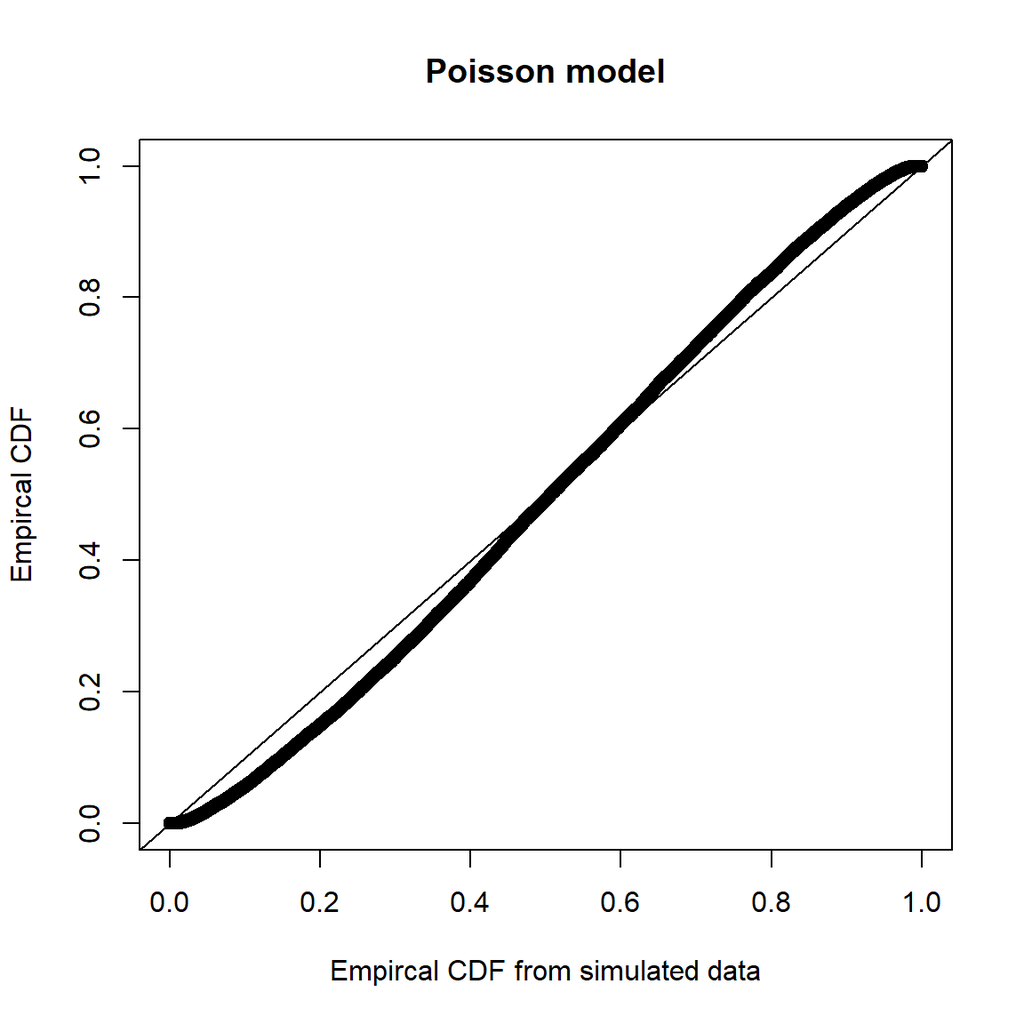

Figure 1: QQ plot of the initial GeoDiff Poisson background model fit. Major departures from the expected line may indicate model misfit before outlier masking.

```r
initial_dispersion <- notes(spatial_data_no_split)$disper
message(glue::glue("Initial no-split dispersion estimate: {round(initial_dispersion, 4)}"))
```

```r
initial_dispersion_table <- tibble::tibble(
  Metric = "Initial no-split dispersion",
  `Observed value` = format_protocol_number(initial_dispersion),
  `Rerun threshold` = format_protocol_number(params$rerun_dispersion_threshold)
)

protocol_kable(
  initial_dispersion_table,
  align = c("l", "r", "r")
)
```

Table 2: Initial GeoDiff dispersion estimate and the YAML-configured threshold used to decide whether the background model should be refitted.

| Metric | Observed value | Rerun threshold |
| --- | --- | --- |
| Initial no-split dispersion | 2.20299 | 2 |

## Review detected outliers (scrollable tables)

Use the initial diagnostic outputs to identify outlier entries before second-pass fitting.  
These tables show exactly which feature/sample positions were masked before the second model fit.

```r
build_outlier_table <- function(outlier_matrix, outlier_label) {
  idx <- which(outlier_matrix == 1, arr.ind = TRUE)
  if (nrow(idx) == 0) {
    return(tibble::tibble(
      outlier_type = outlier_label,
      note = "No outliers detected for this class."
    ))
  }

  tibble::tibble(
    outlier_type = outlier_label,
    feature_index = idx[, 1],
    sample_index = idx[, 2],
    feature_name = rownames(outlier_matrix)[idx[, 1]],
    sample_name = colnames(outlier_matrix)[idx[, 2]]
  )
}

up_outlier_tbl <- build_outlier_table(
  assayDataElement(spatial_data_no_split, "up_outlier"),
  "up_outlier"
)

low_outlier_tbl <- build_outlier_table(
  assayDataElement(spatial_data_no_split, "low_outlier"),
  "low_outlier"
)

all_outlier_tbl <- dplyr::bind_rows(up_outlier_tbl, low_outlier_tbl)

DT::datatable(
  all_outlier_tbl,
  rownames = FALSE,
  class = "stripe hover cell-border nowrap",
  options = list(
    scrollX = TRUE,
    scrollY = "320px",
    paging = TRUE,
    pageLength = 25,
    dom = "tip"
  )
)
```

Table 3: Detected outlier indices from the initial GeoDiff diagnostics. Use the searchable table to audit the feature and sample positions considered for masking before an optional refit.

| outlier_type | feature_index | sample_index | feature_name | sample_name |
| --- | --- | --- | --- | --- |
| up_outlier | 16263 | 14 | RTS0039274 | GSM7084890_DSP-1001660007414-H-F03.dcc |
| up_outlier | 16262 | 63 | RTS0039273 | GSM7084939_DSP-1001660009838-F-D09.dcc |
| up_outlier | 16370 | 67 | RTS0039381 | GSM7084943_DSP-1001660009838-F-E01.dcc |
| up_outlier | 16237 | 68 | RTS0039248 | GSM7084944_DSP-1001660009838-F-E02.dcc |
| up_outlier | 16265 | 107 | RTS0039276 | GSM7084983_DSP-1001660009838-F-H05.dcc |
| up_outlier | 16335 | 115 | RTS0039346 | GSM7084991_DSP-1001660012909-A-A02.dcc |
| up_outlier | 18543 | 115 | RTS0051994 | GSM7084991_DSP-1001660012909-A-A02.dcc |
| up_outlier | 18543 | 116 | RTS0051994 | GSM7084992_DSP-1001660012909-A-A03.dcc |
| up_outlier | 16335 | 117 | RTS0039346 | GSM7084993_DSP-1001660012909-A-A04.dcc |
| up_outlier | 18543 | 117 | RTS0051994 | GSM7084993_DSP-1001660012909-A-A04.dcc |

[output cut: 385 more lines]

The next step applies an explicit rerun policy for protocol users:

- if initial dispersion is above `params$rerun_dispersion_threshold`, the notebook can rerun the Poisson background fit;
- if dispersion is within range, the notebook keeps the first-pass fit and does not rerun;
- optional outlier masking before rerun is controlled by `params$mask_outliers_before_rerun`.

```r
# Decision rule for optional refit:
# - Refit only if initial dispersion is above threshold and rerun toggle is enabled.
dispersion_threshold <- params$rerun_dispersion_threshold
dispersion_is_high <- is.finite(initial_dispersion) && (initial_dispersion > dispersion_threshold)
rerun_enabled <- isTRUE(params$rerun_when_high_dispersion)
run_optional_rerun <- rerun_enabled && dispersion_is_high

if (!rerun_enabled) {
  message("Optional Poisson rerun is disabled via params$rerun_when_high_dispersion = FALSE.")
} else if (!dispersion_is_high) {
  message(
    glue::glue(
      "Dispersion ({round(initial_dispersion, 4)}) <= threshold ({dispersion_threshold}); ",
      "skipping rerun and keeping first-pass model."
    )
  )
} else {
  message(
    glue::glue(
      "Dispersion ({round(initial_dispersion, 4)}) > threshold ({dispersion_threshold}); ",
      "running optional rerun path."
    )
  )
}
```

```
Dispersion (2.203) > threshold (2); running optional rerun path.
```

```r
if (run_optional_rerun && isTRUE(params$mask_outliers_before_rerun)) {
  message("Masking up_outlier/low_outlier entries as NA before optional rerun.")
  assayDataElement(spatial_data, "exprs")[assayDataElement(spatial_data_no_split, "up_outlier") == 1] <- NA
  assayDataElement(spatial_data, "exprs")[assayDataElement(spatial_data_no_split, "low_outlier") == 1] <- NA
} else if (run_optional_rerun) {
  message("Rerun enabled without outlier masking (params$mask_outliers_before_rerun = FALSE).")
}
```

```
Masking up_outlier/low_outlier entries as NA before optional rerun.
```

```r
# Keep first-pass fitted object when rerun is skipped.
if (!run_optional_rerun) {
  spatial_data <- spatial_data_no_split
}
```

```r
# Refit Poisson background only when optional rerun decision is TRUE.
spatial_data <- fitPoisBG(spatial_data)
```

```
Iteration = 1, squared error = 1.756712e+10
```

```
Iteration = 2, squared error = 1.065353e+07
```

```
Iteration = 3, squared error = 3.027856e+04
```

```
Iteration = 4, squared error = 8.600290e+01
```

```
Iteration = 5, squared error = 2.442772e-01
```

```
Iteration = 6, squared error = 6.938300e-04
```

```
Model converged.
```

```r
message("Optional rerun was skipped; using first-pass no-split fitted object for later steps.")
```

```r
# Helper: treat NULL, "", or whitespace-only input as "blank".
is_blank_value <- function(x) {
  if (is.null(x)) return(TRUE)
  if (length(x) == 0) return(TRUE)
  x_chr <- trimws(as.character(x[[1]]))
  is.na(x_chr) || x_chr == ""
}

split_var <- params$split_var
fallback_group_var <- params$fallback_group_var
split_var_is_blank <- is_blank_value(split_var)

# Track whether split fitting was actually run successfully.
use_split <- FALSE

# Validate the fallback grouping column because report summaries rely on it.
if (is_blank_value(fallback_group_var) || !(fallback_group_var %in% colnames(pData(spatial_data)))) {
  stop(
    "fallback_group_var must be a non-blank metadata column in pData(spatial_data). ",
    "Current value: '", fallback_group_var, "'."
  )
}

if (split_var_is_blank) {
  message("No split variable provided -> running non-split path.")
  message(glue::glue("Fallback grouping variable for diagnostics: {fallback_group_var}"))
  fallback_counts <- table(pData(spatial_data)[[fallback_group_var]], useNA = "ifany")
  fit_group_counts <- tibble::tibble(
    `Grouping variable` = fallback_group_var,
    Group = names(fallback_counts),
    `Segment count` = as.integer(fallback_counts)
  )
} else {
  # Keep requiring the user-specified split column when split_var is provided.
  if (!(split_var %in% colnames(pData(spatial_data)))) {
    stop(
      "split_var column '", split_var, "' was not found in pData(spatial_data). ",
      "Available columns include: ", paste(colnames(pData(spatial_data)), collapse = ", ")
    )
  }

  message(glue::glue("Split variable provided: {split_var} -> running split-aware path."))

  # fitPoisBG(..., split_var) can fail with NaN when a split level has too few
  # segments (e.g. only one segment in a slide), so validate split groups first.
  split_counts <- table(pData(spatial_data)[[split_var]], useNA = "ifany")
  fit_group_counts <- tibble::tibble(
    `Grouping variable` = split_var,
    Group = names(split_counts),
    `Segment count` = as.integer(split_counts)
  )
  n_non_missing_levels <- sum(split_counts > 0 & !is.na(names(split_counts)))

  if (n_non_missing_levels < 2) {
    message(
      glue::glue(
        "Split-aware GeoDiff fitting skipped: split variable '{split_var}' has fewer than 2 ",
        "non-missing levels in this dataset. Continuing with non-split fit ",
        "(single-slide/no-split mode)."
      )
    )
  } else if (all(split_counts >= 2)) {
    # Minimal rule: require at least 2 segments per split level.
    # Still guard runtime failures and fall back to non-split fit.
    spatial_data <- tryCatch(
      {
        # Split-mode fit estimates background separately per split level (e.g., slide).
        tmp <- fitPoisBG(spatial_data, split_var)
        use_split <- TRUE
        tmp
      },
      # If split-mode fit fails, preserve previously fitted non-split object.
      error = function(e) {
        message(
          glue::glue(
            "Split-aware fitPoisBG failed ({conditionMessage(e)}). ",
            "Continuing with non-split fit."
          )
        )
        spatial_data
      }
    )
  } else {
    # Report problematic levels so users can decide whether to collapse/relabel groups.
    bad_levels <- names(split_counts)[split_counts < 2]
    message(
      glue::glue(
        "Split-aware GeoDiff fitting skipped: {split_var} levels with <2 segments: ",
        "{paste(bad_levels, collapse = ', ')}. Continuing with non-split fit."
      )
    )
  }
}
```

```
Split variable provided: slide_name -> running split-aware path.
```

```
Iteration = 1, squared error = 7.256216e+10
```

```
Iteration = 2, squared error = 8.777162e+07
```

```
Iteration = 3, squared error = 6.081344e+05
```

```
Iteration = 4, squared error = 4.063959e+03
```

```
Iteration = 5, squared error = 2.659326e+01
```

```
Iteration = 6, squared error = 1.721512e-01
```

```
Iteration = 7, squared error = 1.108504e-03
```

```
Iteration = 8, squared error = 7.119374e-06
```

```
Model converged.
```

```r
final_fit_summary <- dplyr::bind_rows(
  summarise_numeric_metric(pData(spatial_data)$sizefact, "Final sample size factor"),
  summarise_numeric_metric(
    fData(spatial_data)$featfact[fData(spatial_data)$Negative],
    "Final negative-probe feature factor"
  )
)

final_fit_summary_display <- format_metric_summary(final_fit_summary)
```

```r
protocol_kable(
  fit_group_counts,
  align = c("l", "l", "r")
)
```

Table 4: Segment counts for the YAML-selected grouping variable used to assess whether split-aware GeoDiff background fitting is stable.

| Grouping variable | Group | Segment count |
| --- | --- | --- |
| slide_name | 4895-EC-S6 | 64 |
| slide_name | 4895-EC-S7 | 50 |
| slide_name | 6287-EC-S1 | 83 |
| slide_name | 6495-EC-S1 | 80 |

```r
protocol_kable(
  final_fit_summary_display,
  align = c("l", rep("r", ncol(final_fit_summary_display) - 1L))
)
```

Table 5: Final GeoDiff background model summary statistics used by later pipeline stages.

| Metric | Minimum | 1st quartile | Median | Mean | 3rd quartile | Maximum |
| --- | --- | --- | --- | --- | --- | --- |
| Final sample size factor | 0.000261981 | 0.00122017 | 0.00217433 | 0.00361011 | 0.00426381 | 0.0242149 |
| Final negative-probe feature factor | 6,255 | 8,258 | 9,174 | 9,940.86 | 10,262 | 59,990.8 |

```r
set.seed(params$seed)
# Diagnostics
# Run diagnostics on the final model; `split` matches whether split-fit succeeded.
spatial_data <- diagPoisBG(spatial_data, split = use_split)
```

```
The results are based on stored `groupvar`, slide_name
```

```r
# Save the final background-model QQ plot as a 300 dpi PNG (manuscript Figure 3B).
if (isTRUE(params$save_plots)) {
  try({
    .geodiff_final_qq <- grDevices::recordPlot()
    grDevices::png(path(out_figures, "final_poisson_qq.png"),
                   width = 6, height = 6, units = "in", res = 300)
    grDevices::replayPlot(.geodiff_final_qq)
    grDevices::dev.off()
  }, silent = TRUE)
}
```

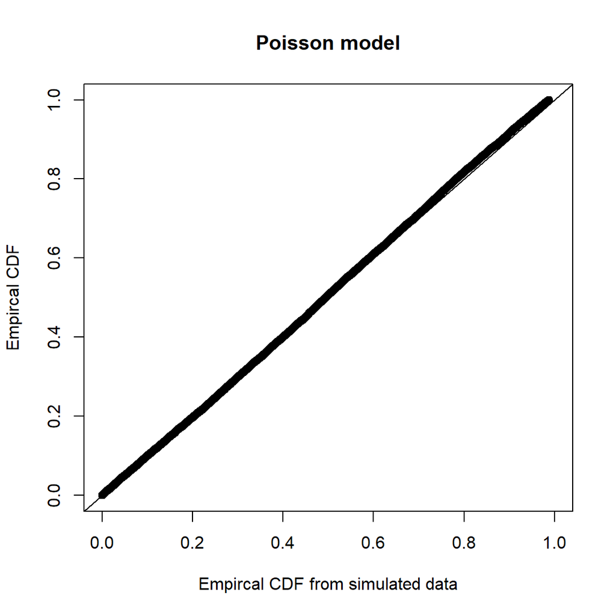

Figure 2: QQ plot of the final GeoDiff Poisson background model after the configured split or no-split fitting path. Major departures from the expected line may indicate residual model misfit before probe aggregation and segment filtering.

```r
final_dispersion <- notes(spatial_data)$disper
```

```r
final_dispersion_table <- tibble::tibble(
  Metric = "Final model dispersion",
  `Observed value` = format_protocol_number(final_dispersion)
)

protocol_kable(
  final_dispersion_table,
  align = c("l", "r")
)
```

Table 6: Final GeoDiff dispersion estimate after the selected background-model fitting path.

| Metric | Observed value |
| --- | --- |
| Final model dispersion | 1.04912 |

The diagnostic output below provides additional context for negative-probe average count behaviour after fitting.

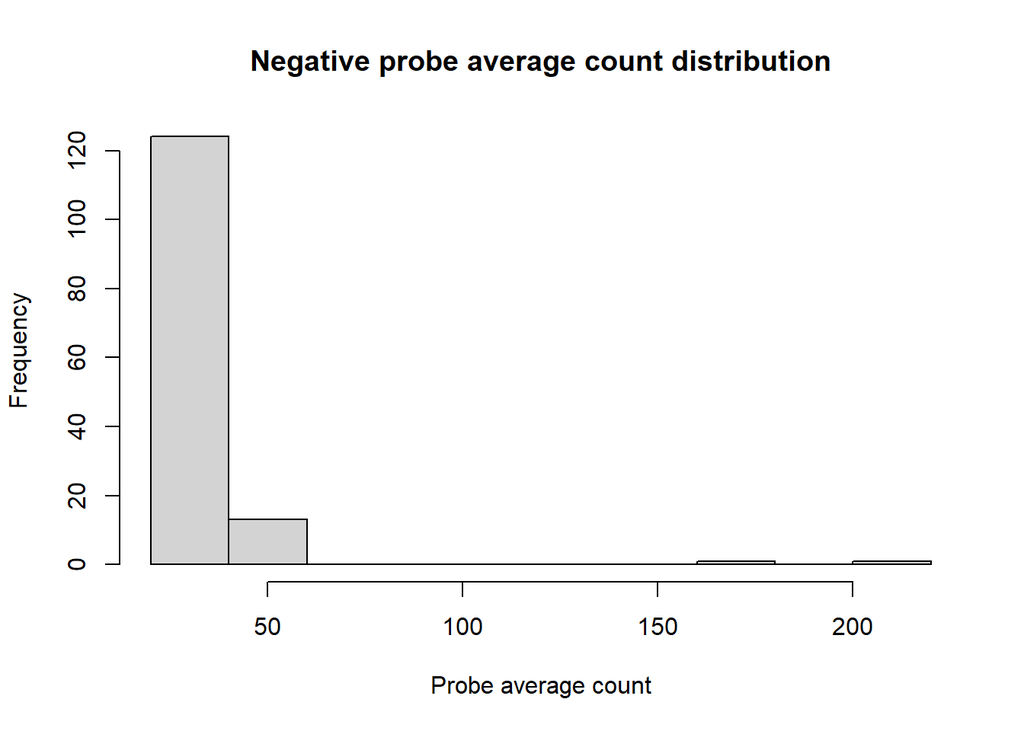

Figure 3: Distribution of average negative-probe counts after final GeoDiff background fitting. A strongly skewed or multimodal distribution may indicate residual background structure that should be reviewed before proceeding.

```r
hist(fData(spatial_data)$featfact[fData(spatial_data)$Negative]/dim(spatial_data)[2], xlab="Probe average count", main="Negative probe average count distribution")

# Save the negative-probe average-count histogram as a 300 dpi PNG (manuscript Figure 3C).
if (isTRUE(params$save_plots)) {
  grDevices::png(path(out_figures, "negative_probe_avg_count.png"),
                 width = 7, height = 5, units = "in", res = 300)
  hist(fData(spatial_data)$featfact[fData(spatial_data)$Negative]/dim(spatial_data)[2], xlab="Probe average count", main="Negative probe average count distribution")
  grDevices::dev.off()
}
```

## Aggregate probes

Collapse probes using correlation-based aggregation after removing all-zero probes.

```r
all0probeidx <- which(rowSums(exprs(spatial_data))==0)
# Remove all-zero probes before aggregation to avoid undefined/degenerate correlations.
if (length(all0probeidx) > 0) {
    spatial_data <- spatial_data[-all0probeidx, ]
}

# Run correlation-based aggregation for remaining probes.
spatial_data <- aggreprobe(spatial_data, use = "cor")
```

## Background score test

Run GeoDiff background score testing and compute how many probes pass the configured p-value threshold.

```r
# `BGScoreTest` computes feature-level p-values versus estimated background signal.
# `useprior=TRUE` enables GeoDiff prior regularisation for more stable small-count behavior.
spatial_data <- BGScoreTest(spatial_data,useprior = TRUE)


sum(fData(spatial_data)[["pvalues"]] < params$bg_pvalue_threshold, na.rm = TRUE)
```

```
[1] 12696
```

## Estimate size factors and quantile ranges

Estimate signal-related size factors and quantify agreement across selected quantiles.

**Note**

A seed is set because this process uses random sampling.

```r
# Seed
set.seed(params$seed)



# `fitNBth` fits NB-based signal model and learns thresholded high-signal features/segments.
spatial_data <- fitNBth(spatial_data, split = use_split)
```

```
`threshold_start` is missing. The default value is estimated based on fitPoisBG results with multiple slides.
```

```
Iteration = 1, squared error = 0.000373182973825926
```

```
Iteration = 2, squared error = 3.02196821303302e-06
```

```
Iteration = 3, squared error = 9.93294886582337e-07
```

```
Iteration = 4, squared error = 5.26725927462401e-07
```

```
Iteration = 5, squared error = 4.45278738558273e-07
```

```
Iteration = 6, squared error = 3.01554614537487e-07
```

```
Iteration = 7, squared error = 2.64855940085534e-07
```

```
Iteration = 8, squared error = 1.86775659562504e-07
```

```
Model converged.
```

```r
# Keep only probes flagged as high-signal by GeoDiff NB-threshold model.
features_high <- rownames(fData(spatial_data))[fData(spatial_data)$feature_high_fitNBth == 1]

length(features_high)
```

```
[1] 1500
```

```r
bgMean <- mean(fData(spatial_data)$featfact, na.rm = TRUE)

notes(spatial_data)[["threshold"]]
```

```
[1] 10062.65
```

```r
bgMean
```

```
[1] 9940.859
```

```r
notes(spatial_data)$bgMean <- bgMean

# Compare background-derived and signal-derived size factors; high correlation is expected.
cor(spatial_data$sizefact, spatial_data$sizefact_fitNBth)
```

```
[1] 0.9475402
```

```r
plot(spatial_data$sizefact, spatial_data$sizefact_fitNBth, xlab = "Background Size Factor",
     ylab = "Signal Size Factor")
abline(a = 0, b = 1)

# Save the background-vs-signal size-factor scatter as a 300 dpi PNG (manuscript Figure 3D).
if (isTRUE(params$save_plots)) {
  grDevices::png(path(out_figures, "size_factor_scatter.png"),
                 width = 6, height = 6, units = "in", res = 300)
  plot(spatial_data$sizefact, spatial_data$sizefact_fitNBth, xlab = "Background Size Factor",
       ylab = "Signal Size Factor")
  abline(a = 0, b = 1)
  grDevices::dev.off()
}
```

```r
# get only biological probes
posdat <- spatial_data[-which(fData(spatial_data)$CodeClass == "Negative"), ]
posdat <- exprs(posdat)

quanrange_probs <- unlist(params$quanrange_probs)

quan <- sapply(quanrange_probs, function(y)
  # For each quantile y, compute per-segment quantile across positive probes.
  apply(posdat, 2, function(x) quantile(x, probs = y)))

# Correlate each quantile-derived factor against GeoDiff signal size factor.
corrs <- apply(quan, 2, function(x) cor(x, spatial_data$sizefact_fitNBth))
names(corrs) <- as.character(quanrange_probs)

corrs
```

```
     0.75       0.8       0.9      0.95
0.9730937 0.9747301 0.9763209 0.9759793
```

[output not shown]

[figure not shown]

```r
# `QuanRange` writes quantile-based scaling factors (e.g., Q75/Q80/Q90/Q95) to pData
# so we can compare their agreement with GeoDiff signal size factors. Use split = TRUE
# only when split_var defines sufficiently populated technical batches; keep the default
# global estimate for small, single-slide, or uneven groups.
spatial_data <- QuanRange(
  spatial_data,
  split = isTRUE(params$quanrange_split),
  probs = quanrange_probs
)

corrs <- apply(pData(spatial_data)[, as.character(quanrange_probs)], 2, function(x)
  # Re-evaluate quantile-vs-sizefactor correlations after QuanRange writes pData columns.
  cor(x, spatial_data$sizefact_fitNBth))

names(corrs) <- as.character(quanrange_probs)

corrs
```

# Save GeoDiff-filtered count object

Apply segment retention criteria from params and save the resulting GeoDiff-filtered count object for later stages.

The retained-segment count reports how many segments remain after GeoDiff filtering. Use this number to confirm that filtering has preserved enough profiled segments for normalization and differential expression analysis.

At this point, the saved object still carries count-like expression in `exprs`. Stage 3 uses this GeoDiff-filtered count data to create the GeoDiff-normalized `normmat` assay, and Stage 5 uses this same count data for count-based voom/dream branches.

```r
ROIs_high <- sampleNames(spatial_data)[
  # Retain segments whose adjusted signal exceeds configured threshold.
  which(
    (quantile(fData(spatial_data)[["para"]][, 1],
              probs = params$roi_para_quantile, na.rm = TRUE) -
       notes(spatial_data)[["threshold"]]) *
      spatial_data$sizefact_fitNBth > params$roi_signal_threshold
  )
]

# Optional diagnostic to check whether segment filtering has dropped an entire disease group.
disease_col <- params$disease_col
if (!is.null(disease_col) && disease_col %in% colnames(pData(spatial_data))) {
  disease_before <- table(pData(spatial_data)[[disease_col]], useNA = "ifany")
  disease_after <- table(pData(spatial_data)[ROIs_high, disease_col], useNA = "ifany")

  disease_filter_table <- dplyr::full_join(
    tibble::enframe(disease_before, name = disease_col, value = "roi_count_before_filtering"),
    tibble::enframe(disease_after, name = disease_col, value = "roi_count_after_filtering"),
    by = disease_col
  ) %>%
    dplyr::mutate(
      roi_count_before_filtering = tidyr::replace_na(.data$roi_count_before_filtering, 0L),
      roi_count_after_filtering = tidyr::replace_na(.data$roi_count_after_filtering, 0L)
    )
  disease_filter_table_display <- disease_filter_table %>%
    dplyr::transmute(
      `Disease state` = .data[[disease_col]],
      `Segments before filtering` = .data$roi_count_before_filtering,
      `Segments after filtering` = .data$roi_count_after_filtering
    )


  dropped_states <- setdiff(names(disease_before)[disease_before > 0], names(disease_after)[disease_after > 0])
  if (length(dropped_states) > 0) {
    message(
      glue::glue(
        "Review segment filtering: all segments were removed for disease states: ",
        "{paste(dropped_states, collapse = ', ')}. Consider relaxing ",
        "`roi_signal_threshold` or lowering `roi_para_quantile`."
      )
    )
  }
}
```

```r
protocol_kable(
  disease_filter_table_display,
  align = c("l", "r", "r")
)
```

Table 7: Disease-state segment counts before and after GeoDiff segment filtering. Confirm that each required study group retains enough segments for normalization and differential-expression modeling.

| Disease state | Segments before filtering | Segments after filtering |
| --- | --- | --- |
| Healthy | 114 | 114 |
| Tumor | 163 | 163 |

```r
if (isTRUE(params$save_rds)) {
  # Persist only retained segments for normalization and differential expression workflows.
  saveRDS(spatial_data[, ROIs_high], file = geodiff_rds_path)
}

message(glue::glue("Saved GeoDiff-filtered count object: {geodiff_rds_path}"))
```

```
Saved GeoDiff-filtered count object: C:/R/gmx/Example_Dataset/Outputs/2_GeoDiff/results/GeoDiff_spatial_data.RDS
```

```r
message("GeoDiff-filtered count data summary: number of segments retained for later stages.")
```

```
GeoDiff-filtered count data summary: number of segments retained for later stages.
```

```r
message(glue::glue("Segments retained: {length(ROIs_high)}"))
```

```
Segments retained: 277
```